# Subset transcript sequences for Ssd1 targets

Edward Wallace, Edward.Wallace@ed.ac.uk

24 March 2020

A script to get transcripts targeted by Ssd1 from published data, then separate their transcript targets and do motif analysis on them.

Now updated to reflect verified ORFs only, longest transcripts when taken from Pelechano 2013, imputed fixed-length UTRs otherwise, and spliced for mature transcripts only.

```r
txs_fasta <-
    Biostrings::readDNAStringSet(
        here::here("out",
                   "longest_full-ORF_ypd_plus_other_fixed_UTR_length_transcripts_nointrons.fasta")
    )
names(txs_fasta) <-
    names(txs_fasta) %>%
    str_remove("_.*")

five_UTRs_fasta <-
    Biostrings::readDNAStringSet(
        here::here("out",
                   "longest_five_prime_UTRs_keepintrons.fasta")
    )
names(five_UTRs_fasta) <-
    names(five_UTRs_fasta) %>%
    str_remove("_.*")
```

# Lists of mRNAs enriched in Ssd1 binding

## Hogan 2008

Reading data from Hogan 2008 `https://doi.org/10.1371/journal.pbio.0060255.sd003`.

```r
# hoganFDRsall <-
#     here::here("data","Ssd1_targets","Hogan2008_FDR_Dataset_S2.txt") %>%
#     read_tsv(comment="#")
#
# hoganFDRsall

ssd1_data_hogan2008 <-
    here::here("data","Ssd1_targets",
               "journal.pbio.0060255.sd003_Hogan2008_Dataset_S3.xls") %>%
    readxl::read_excel("Ssd1_sam",skip=1,
                       col_names = c("Gene",
                                     "Score",
                                     "Numerator",
                                     "Denominator",
                                     "FoldChange",
                                     "qvalue",
                                     "localfdr")
    )

ssd1_data_hogan2008
```

```
## # A tibble: 5,044 x 7
##    Gene              Score Numerator Denominator FoldChange qvalue localfdr
##    <chr>             <dbl>     <dbl>       <dbl>      <dbl>  <dbl>    <dbl>
##  1 YKL101W_ORF       12.8       4.75       0.371      32.8       0  6.47e-4
##  2 YJL158C_ORF       12.1       3.51       0.289      12.0       0  7.56e-5
##  3 YNL239W_ORF       12.0       2.77       0.232       7.12      0  0.
##  4 YCL051W_ORF       10.4       2.67       0.256       6.92      0  0.
##  5 YOR383C_ORF        8.97      2.92       0.326       8.36      0  6.22e-3
##  6 YJL158C_AAA_29_N…  8.85      3.35       0.378      10.9       0  9.45e-3
##  7 YNL066W_ORF        8.12      4.87       0.599      46.8       0  4.50e-2
##  8 YLR190W_ORF        7.99      3.12       0.391      10.2       0  5.34e-2
##  9 YGR014W_ORF        7.65      2.03       0.265       4.33      0  7.66e-2
## 10 YOR383C_OCH__ORF   7.29      2.84       0.390       8.70      0  9.58e-2
## # … with 5,034 more rows
```

```r
ssd1_targets_hogan2008 <-
    ssd1_data_hogan2008 %>%
    filter(str_detect(Gene,"_ORF"),localfdr < 1) %>%
    pull(Gene) %>%
    str_remove("_.*") %>%
    unique
```

## Hogan 2008 target seqs

```r
ssd1_targets_hogan2008_woseqs <- setdiff(ssd1_targets_hogan2008,names(txs_fasta))

ssd1_targets_hogan2008_seqs <-
    txs_fasta[intersect(ssd1_targets_hogan2008,names(txs_fasta))]

writeXStringSet(ssd1_targets_hogan2008_seqs,
                here::here(
                    "out","Ssd1_targets",
                    "ssd1_targets_hogan2008_localfdr5_longestetcspliced_txseqs.fasta"))
```

The following Ssd1 targets are not in the list of transcript sequences:

```r
ssd1_targets_hogan2008_woseqs
```

```
## [1] "YER138W-A"
```

That suggests that we should make educated guesses for those UTRs.

```r
ssd1_targets_hogan2008_5UTR_seqs <-
    five_UTRs_fasta[intersect(ssd1_targets_hogan2008,names(five_UTRs_fasta))]

writeXStringSet(ssd1_targets_hogan2008_5UTR_seqs,
                here::here(
                    "out","Ssd1_targets",
                    "ssd1_targets_hogan2008_localfdr5_5UTRs_keepintrons.fasta"))

writeXStringSet(ssd1_targets_hogan2008_5UTR_seqs[
  width(ssd1_targets_hogan2008_5UTR_seqs) > 15 ],
                here::here(
                    "out","Ssd1_targets",
                    "ssd1_targets_hogan2008_localfdr5_5UTRs_keepintrons_minwidth15.fasta"))
```

## Jansen 2009

Reading data from Jansen 2009.

Surprisingly, the gene systematic names in this table are not completely systematic.

```r
ssd1_data_jansen2009 <-
    here::here("data","Ssd1_targets",
               "NIHMS158901-supplement-02.xls") %>%
    readxl::read_excel(sheet=1)

ssd1_data_jansen2009
```

```
## # A tibble: 172 x 23
##    ProbeID Sequence PerfectHits chrom start end   `Score(d)` `Numerator(r)`
##    <chr>   <chr>          <dbl> <chr> <chr> <chr>      <dbl>          <dbl>
##  1 SC5p.Y… TACCGCG…           1 chr14 5015… 5016…      15.3            7.70
##  2 SC5p.Y… CAGAAAT…           1 chr11 2501… 2502…       4.78           7.59
##  3 SC5p.Y… CGGTATC…           1 chr11 2520… 2521…       4.43           7.51
##  4 SC5p.Y… TTTTGAA…           1 chr12 5354… 5355…       6.94           7.18
##  5 SCorf.… GGACATT…           1 chr3  36821 36890       6.20           6.12
##  6 SCint.… TCAATTA…           1 chr11 5203… 5204…       4.15           5.84
##  7 SCint.… GTATCCC…           1 chr7  2003… 2004…       4.46           5.61
##  8 YKL101… TTGTAAA…           1 chr11 2529… 2530…       4.47           5.54
##  9 SCorf.… ACACATT…           1 chr3  36598 36667       4.65           5.50
## 10 YLR190… GTTGCTT…           1 chr12 5365… 5366…       6.93           5.40
## # … with 162 more rows, and 15 more variables: `Denominator(s+s0)` <dbl>,
## #   `Fold Change` <dbl>, `q-value(%)` <dbl>, `localfdr(%)` <dbl>,
## #   strand <chr>, `inter/genic?` <chr>, `gene name` <chr>, sys_id <chr>,
## #   `probe strand` <chr>, `left_gene sys id` <chr>, `left gene
## #   name` <chr>, left_gene_dist <chr>, `right_gene sys id` <chr>, `right
## #   gene name` <chr>, right_gene_dist <chr>
```

```r
# Here we have to take some effort to get systematic names for all targets
ssd1_genic_targets_jansen2009 <-
    ssd1_data_jansen2009 %>%
    filter(`inter/genic?`=="genic") %>%
    pull(sys_id)

ssd1_intergenic_targets_jansen2009 <-
    c(ssd1_data_jansen2009 %>%
          filter(`inter/genic?`!="genic",`sys_id`==`left gene name`) %>%
          pull(`left_gene sys id`),
      ssd1_data_jansen2009 %>%
          filter(`inter/genic?`!="genic",`sys_id`==`right gene name`) %>%
          pull(`right_gene sys id`)
    )

ssd1_targets_jansen2009 <- unique( c(ssd1_genic_targets_jansen2009,
                                     ssd1_intergenic_targets_jansen2009) )
```

## Jansen 2009 target seqs

```r
ssd1_targets_jansen2009_woseqs <- setdiff(ssd1_targets_jansen2009,names(txs_fasta))

ssd1_targets_jansen2009_seqs <-
    txs_fasta[intersect(ssd1_targets_jansen2009,names(txs_fasta))]

writeXStringSet(ssd1_targets_jansen2009_seqs,
                here::here(
                    "out","Ssd1_targets",
                    "ssd1_targets_jansen2009_localfdr5_longestetcspliced_txseqs.fasta"))
```

The following Ssd1 targets are not in the list of transcript sequences:

```r
ssd1_targets_jansen2009_woseqs
```

```
## [1] "BUD25"     "YHR145C"   "YML084W"   "YDR327W"   "YMR317W"   "YCL001W-B"
## [7] "YHL041W"
```

These are dubious or otherwise non-verified ORFs.

## Hose 2020

```r
ssd1_data_hose2020 <-
    here::here("data","Ssd1_targets",
               "elife-52063-supp2-v2_Hose2020.xlsx") %>%
    readxl::read_excel(range = "A2:E6715",
                       col_names = c("Gene",
                                     "Annotation",
                                     "Bound",
                                     "RNA_DE",
                                     "Prot_DE")
    )

ssd1_data_hose2020
```

```
## # A tibble: 6,714 x 5
##    Gene    Annotation                                  Bound RNA_DE Prot_DE
##    <chr>   <chr>                                       <chr> <chr>  <chr>
##  1 YBR162C YBR162C    ...    TOS1    biological proce… yes   .      yes
##  2 YDL055C YDL055C    ...    PSA1    protein amino ac… yes   .      yes
##  3 YFR033C YFR033C    ...    QCR6    aerobic respirat… yes   .      yes
##  4 YGR282C "YGR282C    ...    BGL2    cell wall organ… yes   .      yes
##  5 YIL123W YIL123W    ...    SIM1    microtubule cyto… yes   yes    yes
##  6 YJL158C YJL158C    ...    CIS3    cell wall organi… yes   yes    yes
##  7 YJL159W YJL159W    ...    HSP150    cell wall orga… yes   .      yes
##  8 YKL101W YKL101W    ...    HSL1    protein amino ac… yes   .      yes
##  9 YKR042W YKR042W    ...    UTH1    mitochondrion or… yes   .      yes
## 10 YLR110C YLR110C    ...    CCW12    cell wall organ… yes   .      yes
## # … with 6,704 more rows
```

```r
ssd1_targets_hose2020 <-
    ssd1_data_hose2020 %>%
    filter(Bound=="yes") %>%
    pull(Gene)
```

## Hose 2020_seqs

```r
ssd1_targets_hose2020_woseqs <- setdiff(ssd1_targets_hose2020,names(txs_fasta))

ssd1_targets_hose2020_seqs <-
    txs_fasta[intersect(ssd1_targets_hose2020,names(txs_fasta))]

writeXStringSet(ssd1_targets_hose2020_seqs,
                here::here(
                    "out","Ssd1_targets",
                    "ssd1_targets_hose2020_fdr5_longestetcspliced_txseqs.fasta"))
```

The following Ssd1 targets are not in the list of transcript sequences:

```r
ssd1_targets_hose2020_woseqs
```

```
## [1] "YGR079W"   "YLR177W"   "YMR304C-A" "YDR134C"   "YPR087W"   "YMR316C-A"
```

```r
ssd1_targets_hose2020_5UTR_seqs <-
    five_UTRs_fasta[intersect(ssd1_targets_hose2020,names(five_UTRs_fasta))]

writeXStringSet(ssd1_targets_hose2020_5UTR_seqs,
                here::here(
                    "out","Ssd1_targets",
                    "ssd1_targets_hose2020_fdr5_5UTRs_keepintrons.fasta"))

writeXStringSet(ssd1_targets_hose2020_5UTR_seqs[
  width(ssd1_targets_hose2020_5UTR_seqs) > 15 ],
                here::here(
                    "out","Ssd1_targets",
                    "ssd1_targets_hose2020_fdr5_5UTRs_keepintrons_minwidth15.fasta"))
```

# Venn diagram of intersections

Ugly yet effective.

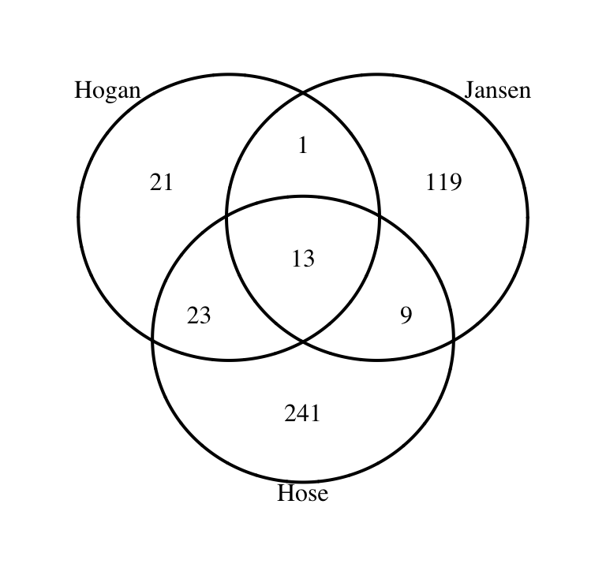

```r
venn(Hogan=ssd1_targets_hogan2008,
     Jansen=ssd1_targets_jansen2009,
     Hose=ssd1_targets_hose2020)
```

## Bayne targets

Removing dubious ORFs ets that don’t have assigned gene names.

```r
ssd1_data_bayne2020 <-
    here::here("data","Ssd1_targets",
               "Ssd1_targets_TPMratio5x_30C_EW1Apr2020.txt") %>%
    readr::read_tsv()
ssd1_data_bayne2020_42C <-
    here::here("data","Ssd1_targets",
               "Ssd1_targets_TPMratio5x_42C_EW1Apr2020.txt") %>%
    readr::read_tsv()
ssd1_targets_bayne2020 <-
    ssd1_data_bayne2020 %>%
    filter(!is.na(Name)) %>%
    pull(Gene)

ssd1_targets_bayne2020_42C <-
    ssd1_data_bayne2020_42C %>%
    filter(!is.na(Name)) %>%
    pull(Gene)
```

# Venn diagram of intersections with all datasets

Ugly yet effective.

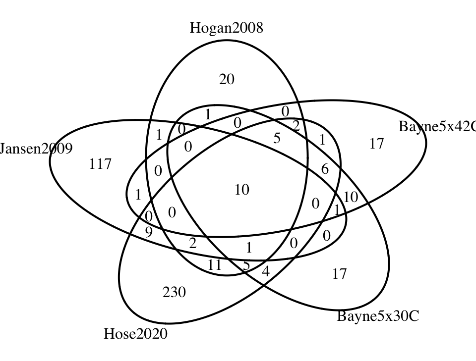

```r
venn(Hogan2008=ssd1_targets_hogan2008,
     Jansen2009=ssd1_targets_jansen2009,
     Hose2020=ssd1_targets_hose2020,
     Bayne5x30C=ssd1_targets_bayne2020,
     Bayne5x42C=ssd1_targets_bayne2020_42C)
```

### What are the genes common to all datasets?

First make a gene-name data frame to show nice gene names:

```r
gene_name_df <-
  here::here("data","saccharomyces_cerevisiae_R64-2-1_20150113.gff") %>%
    read_tsv(col_names=FALSE,comment="#") %>%
    filter(X3=="gene") %>%
    transmute(Gene = str_extract(X9,"Name=[\\w-]+") %>%
                str_remove("Name="),
              Name = str_extract(X9,"gene=[\\w]+") %>%
                str_remove("gene="))
```

Then find the intersection. Generously, we are taking 5x enriched targets in Bayne 2020 at either 30 or 42C.

```r
ssd1_targets_10common <-
    union(ssd1_targets_bayne2020, ssd1_targets_bayne2020_42C) %>%
    intersect(ssd1_targets_hogan2008) %>%
    intersect(ssd1_targets_jansen2009) %>%
    intersect(ssd1_targets_hose2020)

filter(gene_name_df,Gene %in% ssd1_targets_10common)
```

```
## # A tibble: 11 x 2
##    Gene    Name
##    <chr>   <chr>
##  1 YBR162C TOS1
##  2 YCL051W LRE1
##  3 YGR279C SCW4
##  4 YHR143W DSE2
##  5 YIL123W SIM1
##  6 YKL101W HSL1
##  7 YKR042W UTH1
##  8 YLR190W MMR1
##  9 YLR286C CTS1
## 10 YNL066W SUN4
## 11 YOR247W SRL1
```

## Smaller Venn diagrams of intersections with our data

Only including the more conservative Hogan 2008 and Jansen 2009.

### Hogan 2008 vs Jansen 2009 vs Bayne 30C

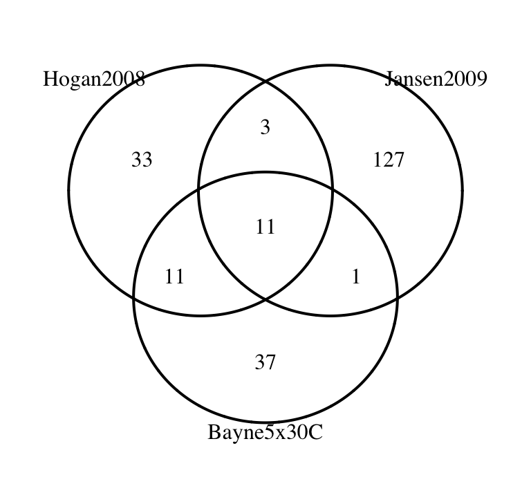

```r
venn(Hogan2008=ssd1_targets_hogan2008,
     Jansen2009=ssd1_targets_jansen2009,
     # Hose2020=ssd1_targets_hose2020,
     Bayne5x30C=ssd1_targets_bayne2020)
```

### Hogan vs 30C vs 42C

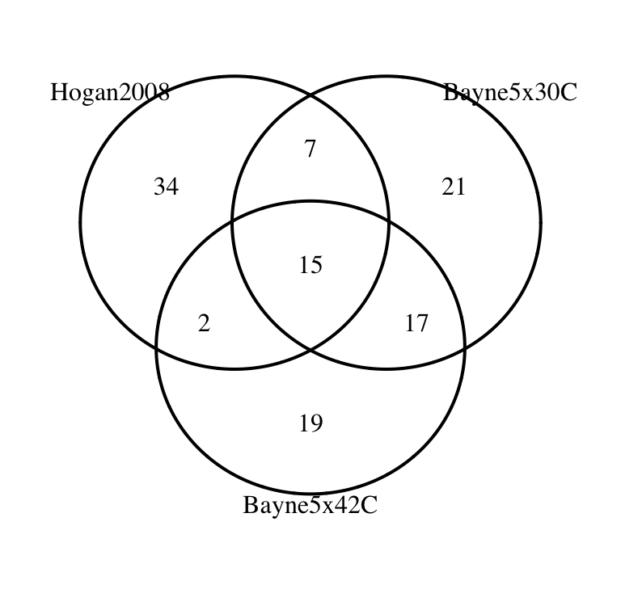

```r
venn(Hogan2008=ssd1_targets_hogan2008,
     #Jansen2009=ssd1_targets_jansen2009,
     # Hose2020=ssd1_targets_hose2020,
     Bayne5x30C=ssd1_targets_bayne2020,
     Bayne5x42C=ssd1_targets_bayne2020_42C)
```

# To do:

- MEME analysis in Differential Enrichment mode, Ssd1 targets vs other